# Tractament vs. Control

Aida Fernandez, 1497182

## Gestió de les dades

Llegim les dades *pesosIndividuales.xlsx*

Posem les variables “Box” i “Treat” com a factors.

```
##  [1] "1"  "2"  "3"  "4"  "5"  "6"  "7"  "8"  "9"  "10" "11" "12" "13" "14" "15"
## [16] "16" "17" "18" "19" "20" "21" "22" "23" "24" "25" "26" "27" "28" "29" "30"
## [31] "31" "32" "33" "34" "35" "36" "37" "38" "39" "40" "41" "42" "43" "44" "45"
## [46] "46" "47" "48" "49" "50" "51" "52" "53" "54" "55" "56" "57" "58" "59" "60"
## [61] "61" "62" "63" "64" "65" "66" "67" "68" "69" "70" "71" "72" "73" "74" "75"
## [76] "76" "77" "78" "79" "80"
```

```
## [1] "1" "2" "3" "4" "5" "6" "7" "8"
```

Creem les següents varibles d’interès.

Guany de pes:
$$BW_{41-28} = BW_{41} - BW_{28}$$

Index de l’increment de pes:
$$Index_{41-28} = 100*\cfrac{BW_{41}}{BW_{28}}$$

Taxa de l’increment de pes:
$$Taxa_{41-28} = 100*\cfrac{BW_{41}-BW_{28}}{BW_{28}}$$

### Tractament de les dades faltants

#### Eliminació de les dades faltants

Si concluim en que la distribució de les dades faltants es pot considerar aleatòria i que n’hi ha poques podem omitir aquestes dades i treure-les de la base de dades sabent que no esbiaixaràn l’anàlisi. Encara que cal tenir en compte que hi haurà una petita pèrdua d’informació.

## Comparació gràfica

Package per a fer layouts de ggplot2

Amb les següents llibraries podrem obtenir ggplots d’una manera considerablement senzilla.

Funció per a simplificar l’obtenció dels histogrames per a comparar tractaments. Els arguments de la funció són:

- “BD” la base de dades.
- “Trac1” i “Tract2” són els tractaments a comparar.
- “TipusGraf” si és 1 representem els histogrames solapant-se al mateix eix de les y, si val 2 representarem els histogrames un a sobre de l’altre pero en diferents eix y.
- “NombreBins” és el nombre de “caixes” en que estarà dividit l’histograma de cadascún dels tractaments, el valor predeterminat és 10.
- “var” és la variable sobre la que es faràn els histogrames.

Histogrames de les noves variables:

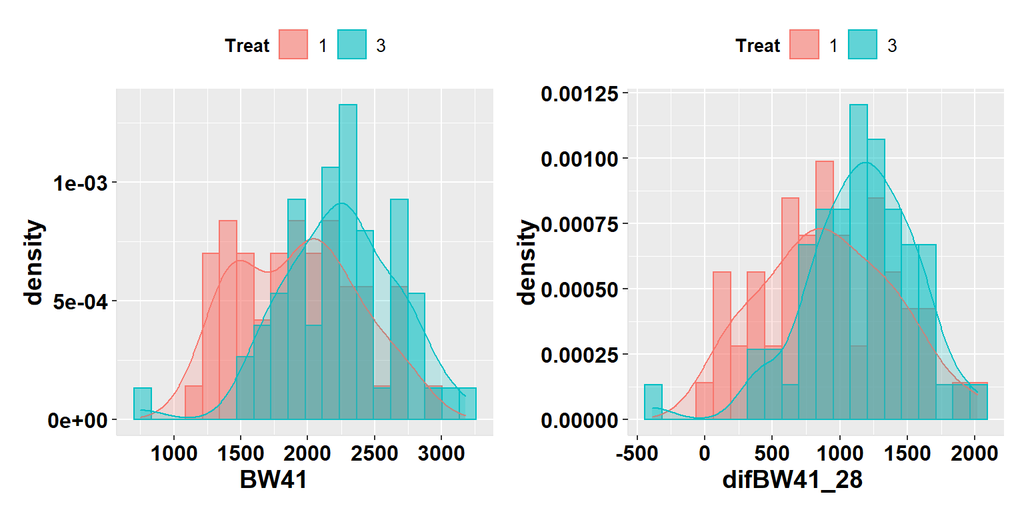

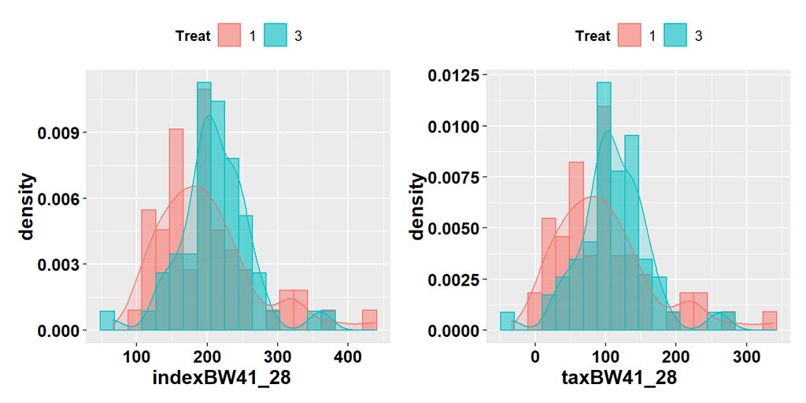

### Comparació de tots els tractaments amb el control

#### Variable *BW41*

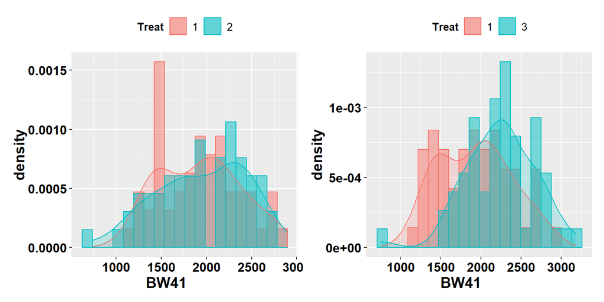

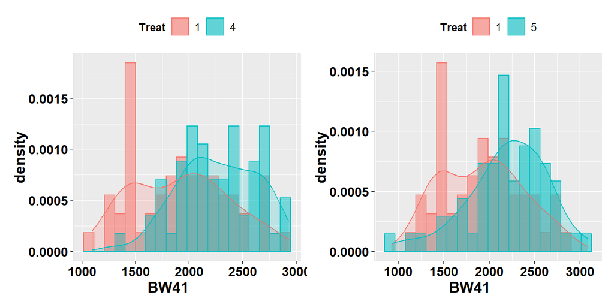

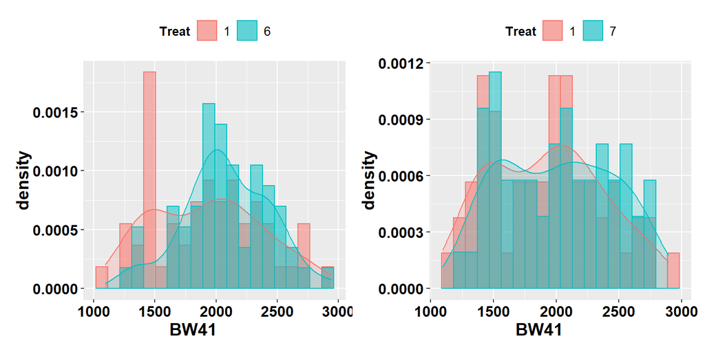

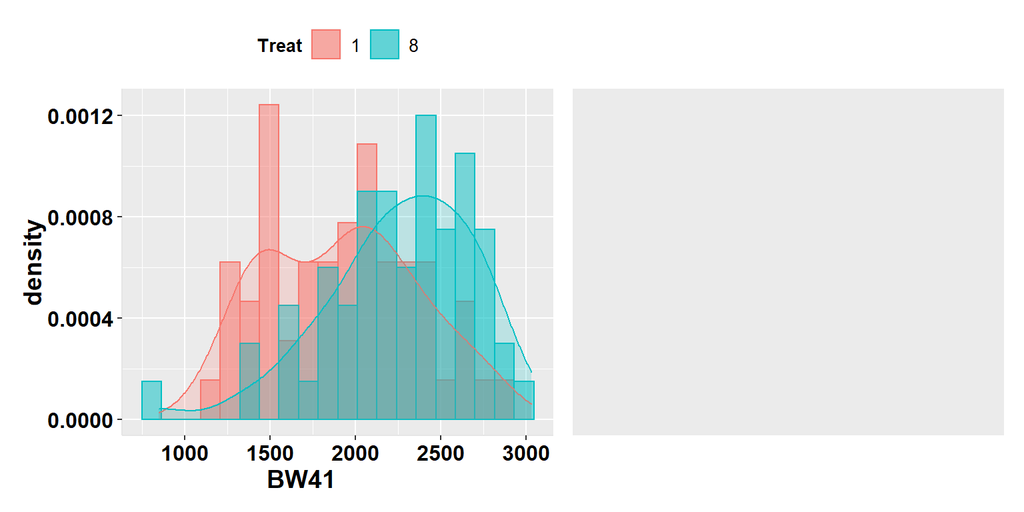

#### Variable *difBW41_28*

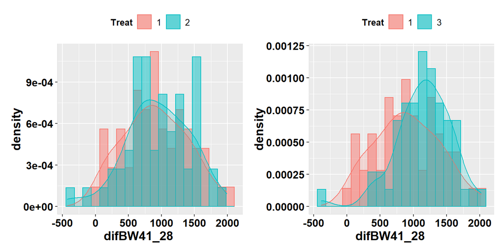

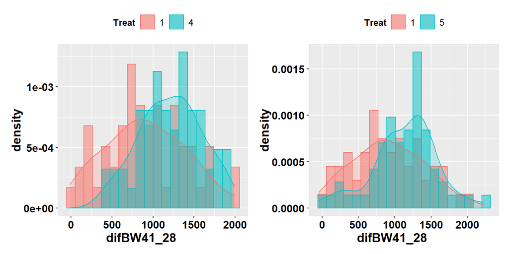

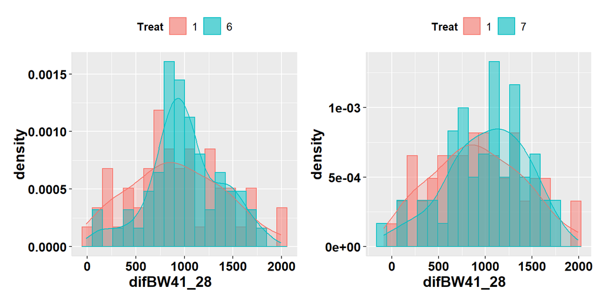

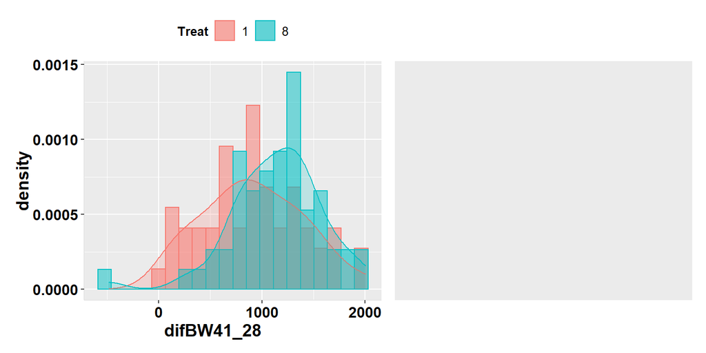

### Two-Sample Rank Test To Detect A Shift In A Proportion Of The “Treated” Population

Test bi-mostral per detectar un canvi positiu en una proporció de la població (tractament) comparada a una altra (control).

quantileTest(x, y, alternative = “greater”, target.quantile = 0.5, target.r = NULL, exact.p = TRUE)

- $x$: Vector numèric d’observacions del grup tractament.
- $y$: Vector numèric d’observacions del grup control.
- $alternative$: Tipus d’hipòtesi alternativa.
  - “greater”: La cua dreta del grup tractament desplaçada cap a la dreta de la cua dreta del grup control.
  - “less”: La cua esquerra del grup tractament desplaçada cap a la esquerra de la cua esquerra del grup control.
- $target.quantile$: Quantil utilitzat com a punt de tall inferior per a la prova. A causa de la naturalesa discreta dels quantils empírics, el límit superior dels possibles quantils empírics sovint difereix del valor de target.quantile.

*$H_1:$ La porció $\epsilon$ de la distribució per al grup de tractament (la distribució de X) es desplaça cap a la dreta de la distribució per al grup de referència (la distribució de Y).*

```
##
##  Quantile Test
##
## data:  subset(pesInd, Treat == 2)$difBW41_28subset(pesInd, Treat == 1)$difBW41_28
## k (# x obs of r largest) = 94, r = 181, m = 115.00000, n = 111.00000,
## quantile.ub = 0.20264, p-value = 0.3206
## alternative hypothesis: true e is  0
```

## Skewness i Kurtosi

```
##            [,1]
## [1,] 1.01156635
## [2,] 0.14219864
## [3,] 0.02626804
## [4,] 2.85914072
## [5,] 0.48532589
## [6,] 0.46443755
## [7,] 0.19728038
## [8,] 0.48394297
```

```
##            [,1]
## [1,]  1.7969308
## [2,]  0.2660273
## [3,]  1.2468064
## [4,] 15.6807456
## [5,]  0.9036873
## [6,]  0.1297607
## [7,] -0.2954785
## [8,]  0.9218744
```

Observem que per la taxa de tots els tractaments existeix una skewness positiva en major o menor mesura, és a dir una cua més llarga a la dreta. Cal destacar que la taxa del tractament 3 podria considerarse pràcticament simètrica.

## Costos

Coste/kg PV (€/kg): La fórmula es: (coste pienso [€/kg] * consumo pienso [kg]) / ganancia peso [kg]

```
##  [1] "Corral"                 "Treat"                  "Consum0-10 (kg)"
##  [4] "Consum10-28(kg)"        "Consum28-41(kg)"        "BW0 (kg)"
##  [7] "BW10 (kg)"              "BW28"                   "BW41"
## [10] "P. prod (\200/kg)"         "Dosi prod (kg/t)"       "P.STARt (\200/kg)"
## [13] "P. GRO (\200/kg)"          "P. FIN(\200/kg)"           "Coste/kg PV (Starter)"
## [16] "Coste/kg PV (Grower)"   "Coste/kg PV (Finisher)"
```

https://www.statisticssolutions.com/transforming-data-for-normality/ https://rcompanion.org/handbook/I_12.html

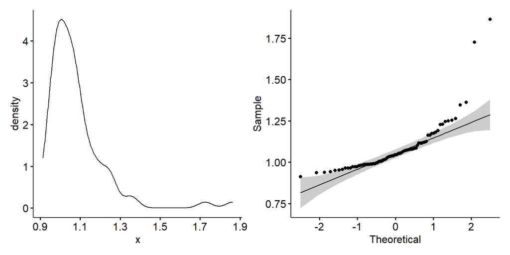

```
##
##  Shapiro-Wilk normality test
##
## data:  c1
## W = 0.71771, p-value = 4.165e-11
```

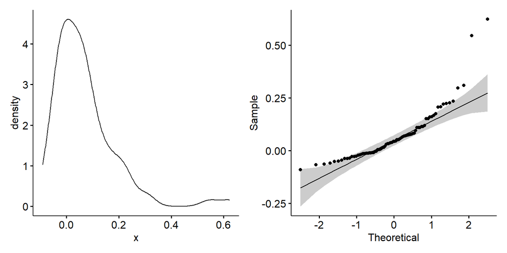

```
##
##  Shapiro-Wilk normality test
##
## data:  c2
## W = 0.81113, p-value = 9.889e-09
```

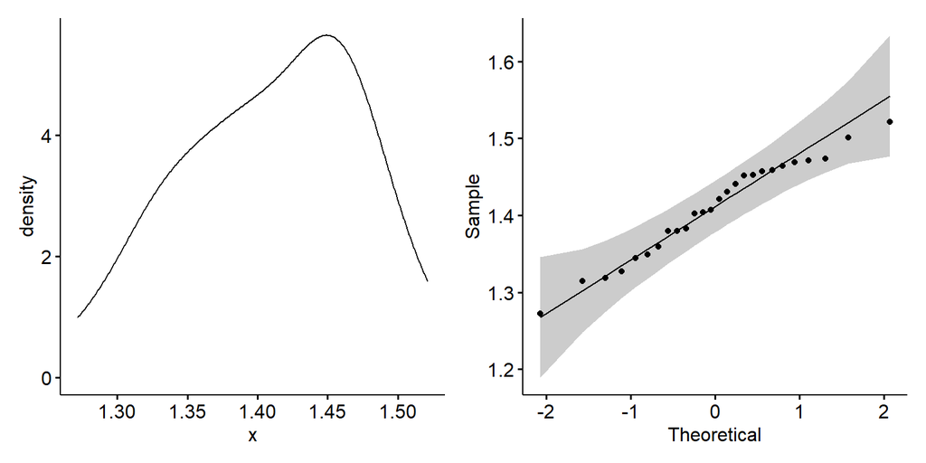

```
##
##  Shapiro-Wilk normality test
##
## data:  c3
## W = 0.96936, p-value = 0.6069
```

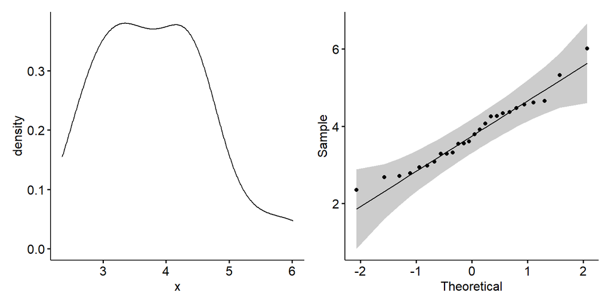

```
##
##  Shapiro-Wilk normality test
##
## data:  c4
## W = 0.96606, p-value = 0.5245
```

```
##
##     lambda      W Shapiro.p.value
## 185   -5.4 0.9906          0.8288
##
## if (lambda >  0){TRANS = x ^ lambda}
## if (lambda == 0){TRANS = log(x)}
## if (lambda <  0){TRANS = -1 * x ^ lambda}
```

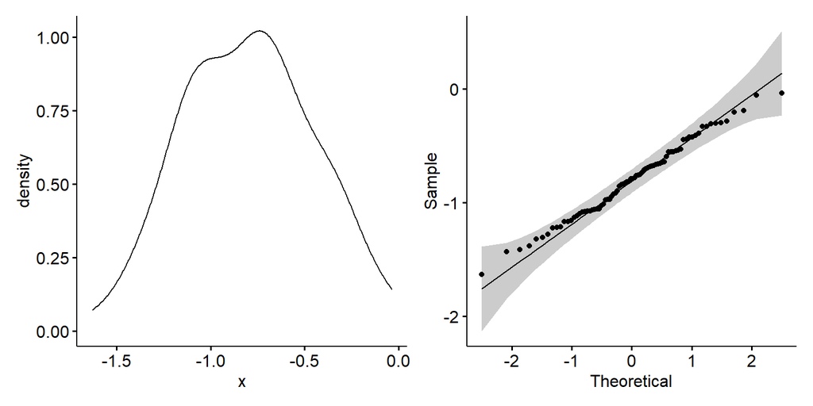

```
##
##  Shapiro-Wilk normality test
##
## data:  c5
## W = 0.99055, p-value = 0.8288
```

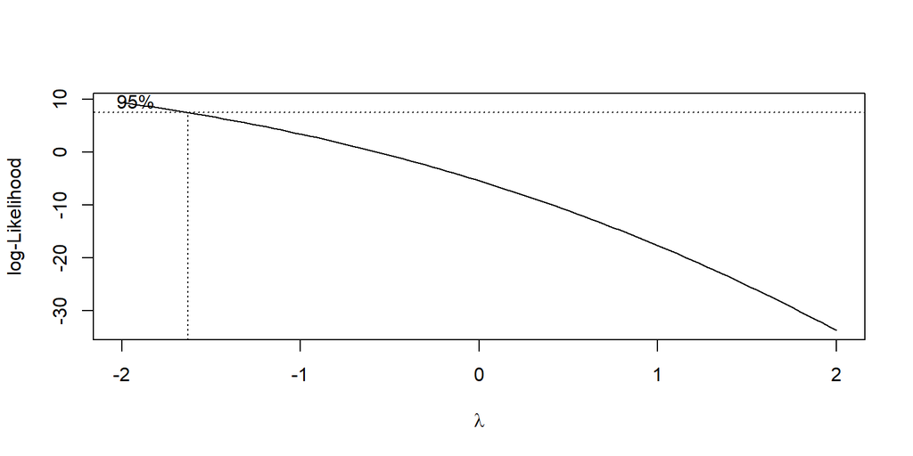

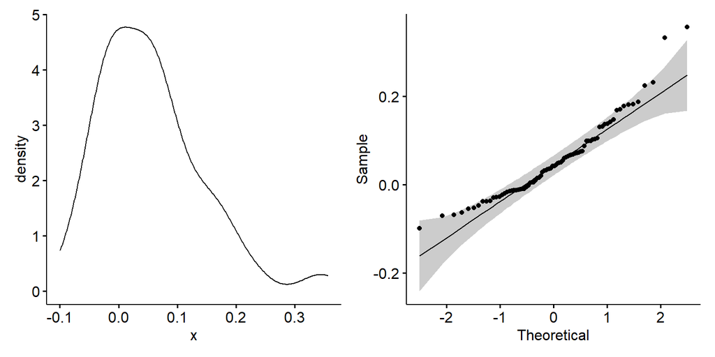

```
##
##  Shapiro-Wilk normality test
##
## data:  c6
## W = 0.93468, p-value = 0.0005051
```

http://www.sthda.com/english/wiki/one-way-anova-test-in-r

```
## tibble [80 x 4] (S3: tbl_df/tbl/data.frame)
##  $ Cost   : num [1:80] 1.07 1.73 1.16 1.07 1.07 ...
##  $ Box    : Factor w/ 80 levels "1","2","3","4",..: 1 11 18 26 34 41 50 60 65 75 ...
##  $ Treat  : Factor w/ 8 levels "1","2","3","4",..: 1 1 1 1 1 1 1 1 1 1 ...
##  $ CostTuk: num [1:80] -0.682 -0.0526 -0.4406 -0.7103 -0.689 ...
```

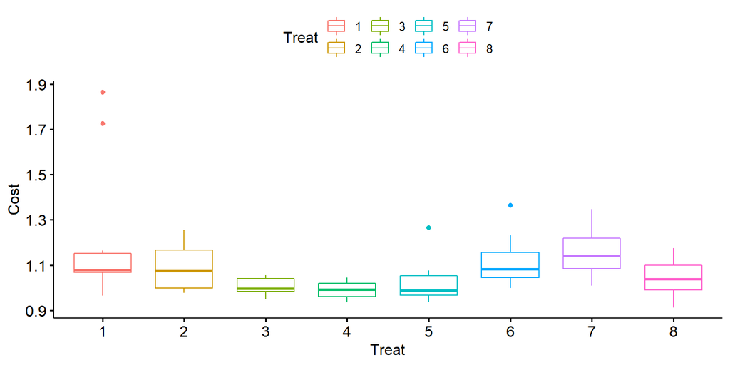

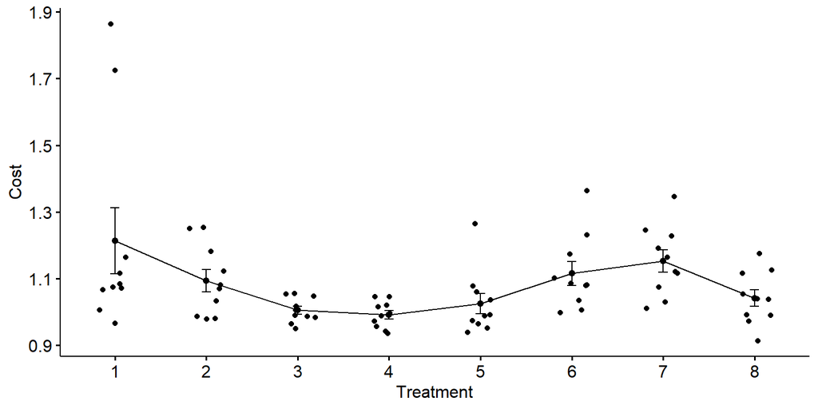

```
##             Df Sum Sq Mean Sq F value   Pr(>F)
## Treat        7  3.035  0.4336   4.881 0.000152 ***
## Residuals   72  6.397  0.0888
## ---
## Signif. codes:  0 '***' 0.001 '**' 0.01 '*' 0.05 '.' 0.1 ' ' 1
```

Tukey multiple pairwise-comparisons

```
##   Tukey multiple comparisons of means
##     95% family-wise confidence level
##
## Fit: aov(formula = CostTuk ~ Treat, data = costos)
##
## $Treat
##            diff         lwr         upr     p adj
## 2-1 -0.10534095 -0.52147417  0.31079227 0.9931367
## 3-1 -0.39553259 -0.81166581  0.02060063 0.0743188
## 4-1 -0.47522197 -0.89135519 -0.05908875 0.0142789
## 5-1 -0.37332879 -0.78946201  0.04280442 0.1109716
## 6-1 -0.03179923 -0.44793244  0.38433399 0.9999976
## 7-1  0.07552814 -0.34060507  0.49166136 0.9991567
## 8-1 -0.27980476 -0.69593797  0.13632846 0.4254439
## 3-2 -0.29019164 -0.70632486  0.12594157 0.3777193
## 4-2 -0.36988102 -0.78601424  0.04625220 0.1177964
## 5-2 -0.26798785 -0.68412106  0.14814537 0.4823023
## 6-2  0.07354172 -0.34259150  0.48967494 0.9992911
## 7-2  0.18086909 -0.23526413  0.59700231 0.8732801
## 8-2 -0.17446381 -0.59059703  0.24166941 0.8926083
## 4-3 -0.07968937 -0.49582259  0.33644384 0.9988066
## 5-3  0.02220380 -0.39392942  0.43833702 0.9999998
## 6-3  0.36373337 -0.05239985  0.77986658 0.1307916
## 7-3  0.47106074  0.05492752  0.88719396 0.0156775
## 8-3  0.11572784 -0.30040538  0.53186105 0.9879685
## 5-4  0.10189317 -0.31424005  0.51802639 0.9943951
## 6-4  0.44342274  0.02728952  0.85955596 0.0286039
## 7-4  0.55075011  0.13461689  0.96688333 0.0023292
## 8-4  0.19541721 -0.22071601  0.61155043 0.8225572
## 6-5  0.34152957 -0.07460365  0.75766279 0.1871716
## 7-5  0.44885694  0.03272372  0.86499016 0.0254839
## 8-5  0.09352404 -0.32260918  0.50965726 0.9967007
## 7-6  0.10732737 -0.30880585  0.52346059 0.9923168
## 8-6 -0.24800553 -0.66413875  0.16812769 0.5818409
## 8-7 -0.35533290 -0.77146612  0.06080032 0.1503343
```

```
##            diff        lwr         upr      p adj
## 2-1 -0.10534095 -0.5214742  0.31079227 0.99313670
## 3-1 -0.39553259 -0.8116658  0.02060063 0.07431879
## 4-1 -0.47522197 -0.8913552 -0.05908875 0.01427889
## 5-1 -0.37332879 -0.7894620  0.04280442 0.11097158
## 6-1 -0.03179923 -0.4479324  0.38433399 0.99999757
## 7-1  0.07552814 -0.3406051  0.49166136 0.99915669
## 8-1 -0.27980476 -0.6959380  0.13632846 0.42544395
```

Multiple comparisons using multcomp package

```
## [1] "summary.glht" "glht"
```

```
##  [1] "model"       "linfct"      "rhs"         "coef"        "vcov"
##  [6] "df"          "alternative" "type"        "focus"       "test"
```

Pairewise t-test

```
##
##  Pairwise comparisons using t tests with pooled SD
##
## data:  costos$CostTuk and costos$Treat
##
##   1      2      3      4      5      6      7
## 2 0.5691 -      -      -      -      -      -
## 3 0.0190 0.0764 -      -      -      -      -
## 4 0.0067 0.0246 0.6277 -      -      -      -
## 5 0.0246 0.0963 0.8682 0.5691 -      -      -
## 6 0.8422 0.6277 0.0248 0.0078 0.0318 -      -
## 7 0.6277 0.2949 0.0067 0.0027 0.0078 0.5691 -
## 8 0.0847 0.3030 0.5691 0.2572 0.5907 0.1249 0.0265
##
## P value adjustment method: BH
```

Check ANOVA assumptions: test validity?

Check the homogeneity of variance assumption

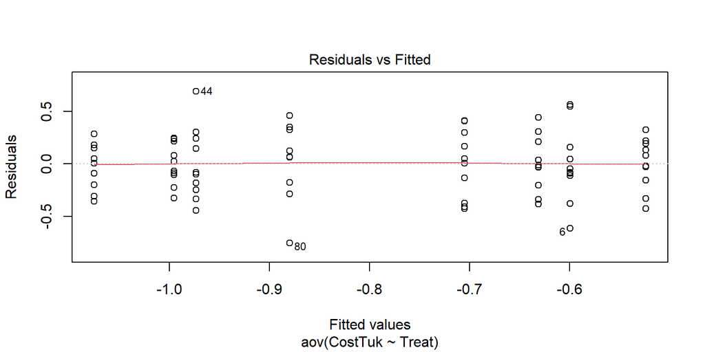

|  | Df | F value | Pr(>F) |
| --- | --- | --- | --- |
| group | 7 | 0.5331627 | 0.8066163 |
|  | 72 | NA | NA |

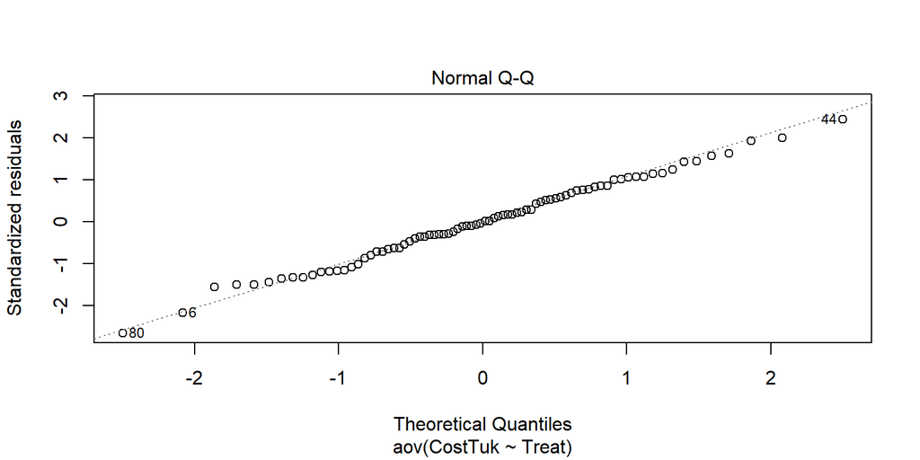

```
##
##  Shapiro-Wilk normality test
##
## data:  residuals(anova)
## W = 0.99411, p-value = 0.9764
```

Non-parametric alternative to one-way ANOVA test

```
##
##  Kruskal-Wallis rank sum test
##
## data:  CostTuk by Treat
## Kruskal-Wallis chi-squared = 26.31, df = 7, p-value = 0.0004432
```